# Intro to Time Series Analysis

Benjamin W Nelson

12/15/2018

# Note

This includes notes taken from the DataCamp Introduction to Time Series Analysis Course.

#### This will cover four basic time series models.

1. White Noise (WN)
2. Random Walk (RW)
3. Autogregression (AR)
4. Simple Moving Average (MA)

# Exploratory

- First you should always use print() to see the Start, End, and Frequency of data
- You can also use length() to see the number of observations
- You should also use plot() to look at the data

```r
#plot(dataframe, xlab = "title", ylab = "title", type = "b") #note that type = "b" provides both data points and a line connecting each point
```

## Sampling Frequency Functions

- start()- time index of the first observation
- end()- time index of the last observation
- frequency()- number of observations per unit time
- deltat()- fixed time increment between observations
- time()- calculates a vector of time indices, with one element for each time index on which the series was observed
- cycle()- returns the position in the cycle of each observation
- plot()- allows you to view the frequency of the data. This function has methods that automatically incorporate time index information into a figure.
- ts.plot()

### Examples

Use the airpassengers dataset

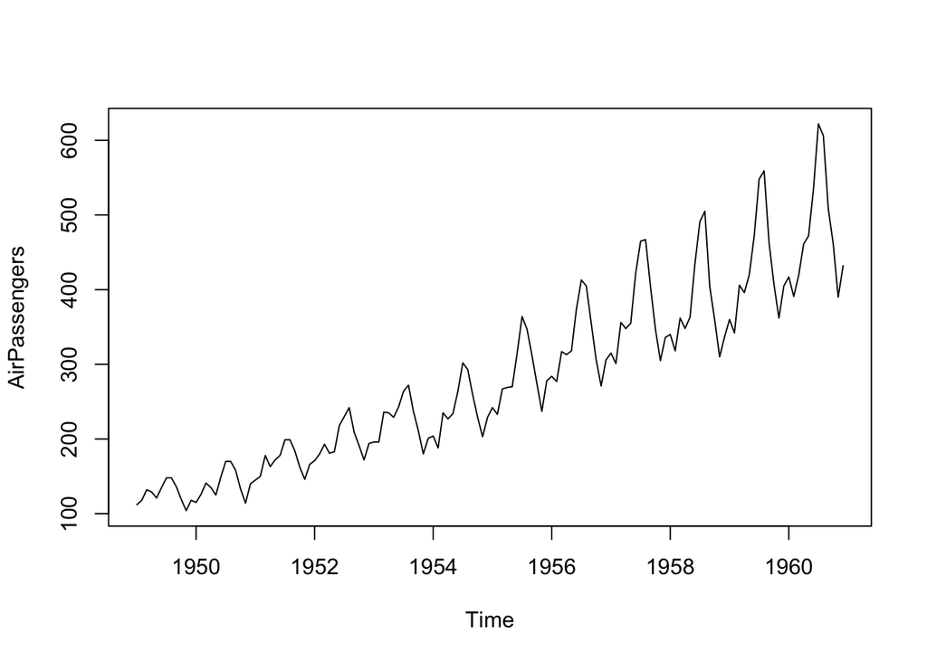

```r
# Plot AirPassengers
plot(AirPassengers)
```

```r
# View the start and end dates of AirPassengers
start(AirPassengers)
```

```
## [1] 1949    1
```

```r
end(AirPassengers)
```

```
## [1] 1960   12
```

```r
# Use time(), deltat(), frequency(), and cycle() with AirPassengers
time(AirPassengers)
```

```
##           Jan      Feb      Mar      Apr      May      Jun      Jul
## 1949 1949.000 1949.083 1949.167 1949.250 1949.333 1949.417 1949.500
## 1950 1950.000 1950.083 1950.167 1950.250 1950.333 1950.417 1950.500
## 1951 1951.000 1951.083 1951.167 1951.250 1951.333 1951.417 1951.500
## 1952 1952.000 1952.083 1952.167 1952.250 1952.333 1952.417 1952.500
## 1953 1953.000 1953.083 1953.167 1953.250 1953.333 1953.417 1953.500
## 1954 1954.000 1954.083 1954.167 1954.250 1954.333 1954.417 1954.500
## 1955 1955.000 1955.083 1955.167 1955.250 1955.333 1955.417 1955.500
## 1956 1956.000 1956.083 1956.167 1956.250 1956.333 1956.417 1956.500
## 1957 1957.000 1957.083 1957.167 1957.250 1957.333 1957.417 1957.500
## 1958 1958.000 1958.083 1958.167 1958.250 1958.333 1958.417 1958.500
## 1959 1959.000 1959.083 1959.167 1959.250 1959.333 1959.417 1959.500
## 1960 1960.000 1960.083 1960.167 1960.250 1960.333 1960.417 1960.500
##           Aug      Sep      Oct      Nov      Dec
## 1949 1949.583 1949.667 1949.750 1949.833 1949.917
## 1950 1950.583 1950.667 1950.750 1950.833 1950.917
## 1951 1951.583 1951.667 1951.750 1951.833 1951.917
## 1952 1952.583 1952.667 1952.750 1952.833 1952.917
## 1953 1953.583 1953.667 1953.750 1953.833 1953.917
## 1954 1954.583 1954.667 1954.750 1954.833 1954.917
## 1955 1955.583 1955.667 1955.750 1955.833 1955.917
## 1956 1956.583 1956.667 1956.750 1956.833 1956.917
## 1957 1957.583 1957.667 1957.750 1957.833 1957.917
## 1958 1958.583 1958.667 1958.750 1958.833 1958.917
## 1959 1959.583 1959.667 1959.750 1959.833 1959.917
## 1960 1960.583 1960.667 1960.750 1960.833 1960.917
```

```r
deltat(AirPassengers)
```

```
## [1] 0.08333333
```

```r
frequency(AirPassengers)
```

```
## [1] 12
```

```r
cycle(AirPassengers)
```

```
##      Jan Feb Mar Apr May Jun Jul Aug Sep Oct Nov Dec
## 1949   1   2   3   4   5   6   7   8   9  10  11  12
## 1950   1   2   3   4   5   6   7   8   9  10  11  12
## 1951   1   2   3   4   5   6   7   8   9  10  11  12
## 1952   1   2   3   4   5   6   7   8   9  10  11  12
## 1953   1   2   3   4   5   6   7   8   9  10  11  12
## 1954   1   2   3   4   5   6   7   8   9  10  11  12
## 1955   1   2   3   4   5   6   7   8   9  10  11  12
## 1956   1   2   3   4   5   6   7   8   9  10  11  12
## 1957   1   2   3   4   5   6   7   8   9  10  11  12
## 1958   1   2   3   4   5   6   7   8   9  10  11  12
## 1959   1   2   3   4   5   6   7   8   9  10  11  12
## 1960   1   2   3   4   5   6   7   8   9  10  11  12
```

# Sampling Frequency

1. Exact- time series data is exactly evenly spaced (e.g., hourly observations)
2. Approximate- time serues data that is approximately evenly spaced (e.g., temperature obsdrvations each time you check your email)
3. Missing Values- time series data that has missing values

# Basic Assumptions of Time Series Data

1. Consecutive observations are evenly spaced
2. Apply a discrete-time observation index
3. These rules may only be true approximately (e.g., daily stock prices are only observed on weekdays and may not be available for certain holidays)

# Basic Time Series Objects

- ts()- this creates a time series object. This represents data that is at least approximatley evenly spaced across time. You can specify aspects of the ts() by adding information ts(dataframe, start = year, frequency = 1)
- is.ts()- this checks whether a given object is a time series

### Example 1

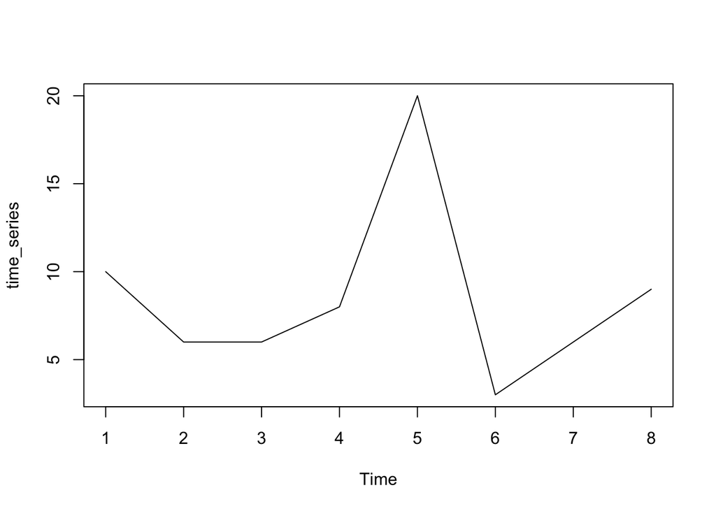

```r
#Simple Time Series
data_vector <- c(10, 6, 6, 8, 20, 3, 6, 9)

#Turn the data vector into time series
time_series <- ts(data_vector)
#plot time series
plot(time_series)
```

### Example 2

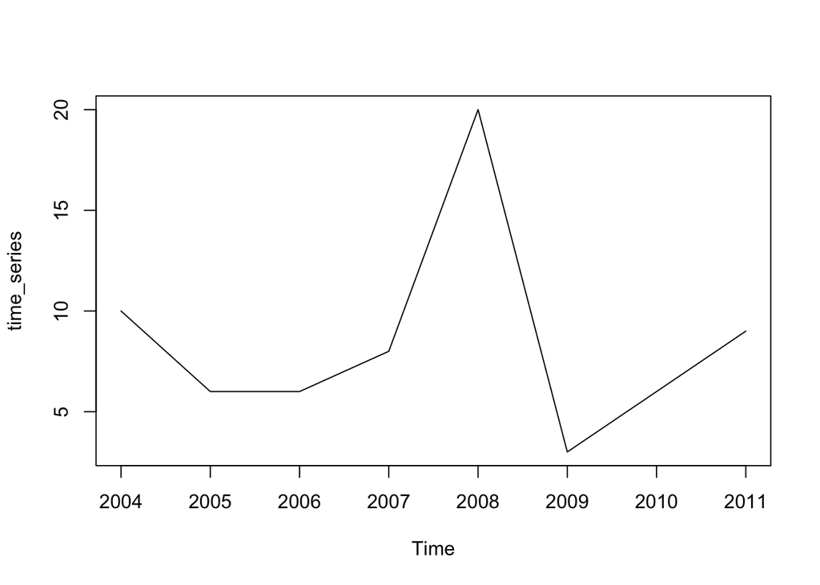

```r
#Instead of starting with 1, you can start with a year and then specify the frequency of observations

#Turn the data vector into time series
time_series <- ts(data_vector, start = 2004, frequency = 1)
#plot time series
plot(time_series)
```

### Example 3

```r
#See if the data vector and time series are time series
is.ts(data_vector) #false
```

```
## [1] FALSE
```

```r
is.ts(time_series) #true
```

```
## [1] TRUE
```

# Time Series Trends

## Types of Trends

1. Linear
2. Rapid Growth
3. Periodic or Sinusodial
4. Variance (i.e., increasing or decreasing variance over time)

## Data Filters to Transform or Remove Different Types of Data Trends

1. log()- this is the natural logarithm transformation. This can linearize a Rapid Growth Trend. This can also stabalize a time series that shows increasing Variance Trend (i.e., variability over time). The one restriction is that it can only be used for positively valued time series data. This will shrink observations greater than one towards zero by small increments and shrink large observations towards zero by greater increments.
2. diff()- this is a difference transformation and it can remove linear trends. This will always have one fewer observation than the original time series data before it was transformed.
3. diff(…, lag = s)- this is for a periodic series. This removes periodic trends. For example if you want to remove seasonal trends (there are four seasons), then you set lag = 4. If you want to remove monthly trends, then you set lag = 12. The default of diff() is lag = 1. Differenced series will have s fewer observations than the original dataset.

# White Noise (WN) Model

### Description:

*Weak white noise* processes are fixed with a constant mean and constant variance and do not have a correlation over time. In other words, if the mean is not constant over time, the variance changes over time, or there seems to be a correlation between patterns in the data across time, then it is not White Noise